# Optimal Treatment Analysis

## Outcome Variable

**Outcome Variable:** haz

## Predictor Variables

**Intervention Variable:** exclfeed36

**Adjustment Set:**

- arm
- sex
- W_mage
- meducyrs
- feducyrs
- hhwealth_quart
- hfoodsec
- W_mhtcm
- vagbrth
- W_gagebrth
- W_birthwt
- W_birthlen
- W_nrooms
- W_nchldlt5
- month
- brthmon
- W_parity
- impfloor
- impsan
- safeh20
- delta_W_mage
- delta_meducyrs
- delta_feducyrs
- delta_hhwealth_quart
- delta_hfoodsec
- delta_W_mhtcm
- delta_vagbrth
- delta_W_gagebrth
- delta_W_birthwt
- delta_W_birthlen
- delta_W_nrooms
- delta_W_nchldlt5
- delta_month
- delta_brthmon
- delta_W_parity
- delta_impfloor
- delta_impsan
- delta_safeh20

## Stratifying Variables

The analysis was stratified on these variable(s):

- agecat
- studyid
- country

## Data Summary

| agecat | studyid | country | exclfeed36 | n_cell | n |
| --- | --- | --- | --- | --- | --- |
| Birth | ki0047075b-MAL-ED | BANGLADESH | 1 | 62 | 243 |
| Birth | ki0047075b-MAL-ED | BANGLADESH | 0 | 181 | 243 |
| Birth | ki0047075b-MAL-ED | BRAZIL | 1 | 13 | 185 |
| Birth | ki0047075b-MAL-ED | BRAZIL | 0 | 172 | 185 |
| Birth | ki0047075b-MAL-ED | INDIA | 1 | 5 | 198 |
| Birth | ki0047075b-MAL-ED | INDIA | 0 | 193 | 198 |
| Birth | ki0047075b-MAL-ED | NEPAL | 1 | 11 | 172 |
| Birth | ki0047075b-MAL-ED | NEPAL | 0 | 161 | 172 |
| Birth | ki0047075b-MAL-ED | PERU | 1 | 15 | 273 |
| Birth | ki0047075b-MAL-ED | PERU | 0 | 258 | 273 |
| Birth | ki0047075b-MAL-ED | SOUTH AFRICA | 1 | 0 | 236 |
| Birth | ki0047075b-MAL-ED | SOUTH AFRICA | 0 | 236 | 236 |
| Birth | ki0047075b-MAL-ED | TANZANIA, UNITED REPUBLIC OF | 1 | 1 | 121 |
| Birth | ki0047075b-MAL-ED | TANZANIA, UNITED REPUBLIC OF | 0 | 120 | 121 |
| Birth | ki1000108-CMC-V-BCS-2002 | INDIA | 1 | 3 | 3 |
| Birth | ki1000108-CMC-V-BCS-2002 | INDIA | 0 | 0 | 3 |
| Birth | ki1000108-IRC | INDIA | 1 | 0 | 4 |
| Birth | ki1000108-IRC | INDIA | 0 | 4 | 4 |
| Birth | ki1000109-EE | PAKISTAN | 1 | 1 | 2 |
| Birth | ki1000109-EE | PAKISTAN | 0 | 1 | 2 |
| Birth | ki1101329-Keneba | GAMBIA | 1 | 363 | 1252 |
| Birth | ki1101329-Keneba | GAMBIA | 0 | 889 | 1252 |
| Birth | kiGH5241-JiVitA-3 | BANGLADESH | 1 | 11155 | 13946 |
| Birth | kiGH5241-JiVitA-3 | BANGLADESH | 0 | 2791 | 13946 |
| Birth | kiGH5241-JiVitA-4 | BANGLADESH | 1 | 580 | 727 |
| Birth | kiGH5241-JiVitA-4 | BANGLADESH | 0 | 147 | 727 |
| 6 months | ki0047075b-MAL-ED | BANGLADESH | 1 | 63 | 240 |
| 6 months | ki0047075b-MAL-ED | BANGLADESH | 0 | 177 | 240 |
| 6 months | ki0047075b-MAL-ED | BRAZIL | 1 | 17 | 209 |
| 6 months | ki0047075b-MAL-ED | BRAZIL | 0 | 192 | 209 |

[output cut: 60 more lines]

The following strata were considered:

- agecat: 24 months, studyid: ki0047075b-MAL-ED, country: BANGLADESH
- agecat: 24 months, studyid: ki0047075b-MAL-ED, country: BRAZIL
- agecat: 24 months, studyid: ki0047075b-MAL-ED, country: INDIA
- agecat: 24 months, studyid: ki0047075b-MAL-ED, country: NEPAL
- agecat: 24 months, studyid: ki0047075b-MAL-ED, country: PERU
- agecat: 24 months, studyid: ki0047075b-MAL-ED, country: SOUTH AFRICA
- agecat: 24 months, studyid: ki0047075b-MAL-ED, country: TANZANIA, UNITED REPUBLIC OF
- agecat: 24 months, studyid: ki1000108-CMC-V-BCS-2002, country: INDIA
- agecat: 24 months, studyid: ki1000108-IRC, country: INDIA
- agecat: 24 months, studyid: ki1017093b-PROVIDE, country: BANGLADESH
- agecat: 24 months, studyid: ki1101329-Keneba, country: GAMBIA
- agecat: 24 months, studyid: ki1113344-GMS-Nepal, country: NEPAL
- agecat: 24 months, studyid: ki1148112-LCNI-5, country: MALAWI
- agecat: 24 months, studyid: kiGH5241-JiVitA-3, country: BANGLADESH
- agecat: 24 months, studyid: kiGH5241-JiVitA-4, country: BANGLADESH
- agecat: 6 months, studyid: ki0047075b-MAL-ED, country: BANGLADESH
- agecat: 6 months, studyid: ki0047075b-MAL-ED, country: BRAZIL
- agecat: 6 months, studyid: ki0047075b-MAL-ED, country: INDIA
- agecat: 6 months, studyid: ki0047075b-MAL-ED, country: NEPAL
- agecat: 6 months, studyid: ki0047075b-MAL-ED, country: PERU
- agecat: 6 months, studyid: ki0047075b-MAL-ED, country: SOUTH AFRICA
- agecat: 6 months, studyid: ki0047075b-MAL-ED, country: TANZANIA, UNITED REPUBLIC OF
- agecat: 6 months, studyid: ki1000108-CMC-V-BCS-2002, country: INDIA
- agecat: 6 months, studyid: ki1000108-IRC, country: INDIA
- agecat: 6 months, studyid: ki1000109-EE, country: PAKISTAN
- agecat: 6 months, studyid: ki1000304b-SAS-FoodSuppl, country: INDIA
- agecat: 6 months, studyid: ki1017093b-PROVIDE, country: BANGLADESH
- agecat: 6 months, studyid: ki1101329-Keneba, country: GAMBIA
- agecat: 6 months, studyid: ki1113344-GMS-Nepal, country: NEPAL
- agecat: 6 months, studyid: ki1148112-LCNI-5, country: MALAWI
- agecat: 6 months, studyid: kiGH5241-JiVitA-3, country: BANGLADESH
- agecat: 6 months, studyid: kiGH5241-JiVitA-4, country: BANGLADESH
- agecat: Birth, studyid: ki0047075b-MAL-ED, country: BANGLADESH
- agecat: Birth, studyid: ki0047075b-MAL-ED, country: BRAZIL
- agecat: Birth, studyid: ki0047075b-MAL-ED, country: INDIA
- agecat: Birth, studyid: ki0047075b-MAL-ED, country: NEPAL
- agecat: Birth, studyid: ki0047075b-MAL-ED, country: PERU
- agecat: Birth, studyid: ki0047075b-MAL-ED, country: SOUTH AFRICA
- agecat: Birth, studyid: ki0047075b-MAL-ED, country: TANZANIA, UNITED REPUBLIC OF
- agecat: Birth, studyid: ki1000108-CMC-V-BCS-2002, country: INDIA
- agecat: Birth, studyid: ki1000108-IRC, country: INDIA
- agecat: Birth, studyid: ki1000109-EE, country: PAKISTAN
- agecat: Birth, studyid: ki1101329-Keneba, country: GAMBIA
- agecat: Birth, studyid: kiGH5241-JiVitA-3, country: BANGLADESH
- agecat: Birth, studyid: kiGH5241-JiVitA-4, country: BANGLADESH

### Dropped Strata

Some strata were dropped due to rare outcomes:

- agecat: Birth, studyid: ki0047075b-MAL-ED, country: SOUTH AFRICA
- agecat: Birth, studyid: ki0047075b-MAL-ED, country: TANZANIA, UNITED REPUBLIC OF
- agecat: Birth, studyid: ki1000108-CMC-V-BCS-2002, country: INDIA
- agecat: Birth, studyid: ki1000108-IRC, country: INDIA
- agecat: Birth, studyid: ki1000109-EE, country: PAKISTAN
- agecat: 6 months, studyid: ki0047075b-MAL-ED, country: SOUTH AFRICA
- agecat: 6 months, studyid: ki0047075b-MAL-ED, country: TANZANIA, UNITED REPUBLIC OF
- agecat: 6 months, studyid: ki1000108-CMC-V-BCS-2002, country: INDIA
- agecat: 6 months, studyid: ki1000108-IRC, country: INDIA
- agecat: 6 months, studyid: ki1000304b-SAS-FoodSuppl, country: INDIA
- agecat: 24 months, studyid: ki0047075b-MAL-ED, country: SOUTH AFRICA
- agecat: 24 months, studyid: ki0047075b-MAL-ED, country: TANZANIA, UNITED REPUBLIC OF
- agecat: 24 months, studyid: ki1000108-CMC-V-BCS-2002, country: INDIA
- agecat: 24 months, studyid: ki1000108-IRC, country: INDIA

## Methods Detail

We’re interested in the causal parameters $E[Y_a]$ for all values of $a \in \mathcal{A}$. These parameters represent the mean outcome if, possibly contrary to fact, we intervened to set all units to have $A=a$. Under the randomization and positivity assumptions, these are identified by the statistical parameters $\psi_a=E_W[E_{Y|A,W}(Y|A=a,W)]$. In addition, we’re interested in the mean of $Y$, $E[Y]$ under no intervention (the observed mean). We will estimate these parameters by using SuperLearner to fit the relevant likelihood factors – $E_{Y|A,W}(Y|A=a,W)$ and $p(A=a|W)$, and then updating our likelihood fit using a joint TMLE.

For unadjusted analyses ($W=\{\}$), initial likelihoods were estimated using Lrnr_glm to estimate the simple $E(Y|A)$ and Lrnr_mean to estimate $p(A)$. For adjusted analyses, a small library containing Lrnr_glmnet, Lrnr_xgboost, and Lrnr_mean was used.

Having estimated these parameters, we will then use the delta method to estimate relative risks and attributable risks relative to a prespecified baseline level of $A$.

# Results Detail

## Results Plots

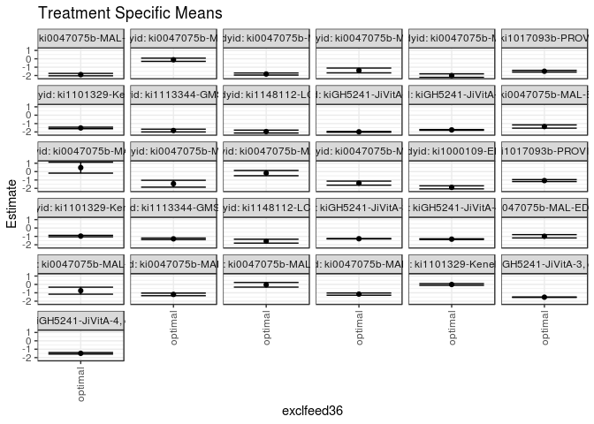

## Results Table

### Parameter: TSM

| agecat | studyid | country | intervention_level | baseline_level | estimate | ci_lower | ci_upper |
| --- | --- | --- | --- | --- | --- | --- | --- |
| Birth | ki0047075b-MAL-ED | BANGLADESH | optimal | observed | -0.9887910 | -1.1856493 | -0.7919328 |
| Birth | ki0047075b-MAL-ED | BRAZIL | optimal | observed | -0.7462005 | -1.1655470 | -0.3268541 |
| Birth | ki0047075b-MAL-ED | INDIA | optimal | observed | -1.1913290 | -1.3475012 | -1.0351568 |
| Birth | ki0047075b-MAL-ED | NEPAL | optimal | observed | -0.0430361 | -0.3189879 | 0.2329156 |
| Birth | ki0047075b-MAL-ED | PERU | optimal | observed | -1.1577325 | -1.2929287 | -1.0225362 |
| Birth | ki1101329-Keneba | GAMBIA | optimal | observed | -0.0089627 | -0.1103254 | 0.0923999 |
| Birth | kiGH5241-JiVitA-3 | BANGLADESH | optimal | observed | -1.5241290 | -1.5507713 | -1.4974867 |
| Birth | kiGH5241-JiVitA-4 | BANGLADESH | optimal | observed | -1.4906189 | -1.5809308 | -1.4003070 |
| 6 months | ki0047075b-MAL-ED | BANGLADESH | optimal | observed | -1.3549108 | -1.5508649 | -1.1589566 |
| 6 months | ki0047075b-MAL-ED | BRAZIL | optimal | observed | 0.4711166 | -0.1828786 | 1.1251119 |
| 6 months | ki0047075b-MAL-ED | INDIA | optimal | observed | -1.4459315 | -1.8554930 | -1.0363699 |
| 6 months | ki0047075b-MAL-ED | NEPAL | optimal | observed | -0.1791867 | -0.4919686 | 0.1335951 |
| 6 months | ki0047075b-MAL-ED | PERU | optimal | observed | -1.3769335 | -1.6185327 | -1.1353342 |
| 6 months | ki1000109-EE | PAKISTAN | optimal | observed | -1.8811283 | -2.0643629 | -1.6978937 |
| 6 months | ki1017093b-PROVIDE | BANGLADESH | optimal | observed | -1.0730927 | -1.1913594 | -0.9548259 |
| 6 months | ki1101329-Keneba | GAMBIA | optimal | observed | -0.9643624 | -1.0495215 | -0.8792034 |
| 6 months | ki1113344-GMS-Nepal | NEPAL | optimal | observed | -1.2930124 | -1.3826621 | -1.2033627 |
| 6 months | ki1148112-LCNI-5 | MALAWI | optimal | observed | -1.5695138 | -1.8021603 | -1.3368674 |
| 6 months | kiGH5241-JiVitA-3 | BANGLADESH | optimal | observed | -1.2800848 | -1.3065147 | -1.2536549 |
| 6 months | kiGH5241-JiVitA-4 | BANGLADESH | optimal | observed | -1.3305928 | -1.3767368 | -1.2844489 |
| 24 months | ki0047075b-MAL-ED | BANGLADESH | optimal | observed | -1.8882039 | -2.0332481 | -1.7431597 |
| 24 months | ki0047075b-MAL-ED | BRAZIL | optimal | observed | -0.1162747 | -0.3079707 | 0.0754214 |
| 24 months | ki0047075b-MAL-ED | INDIA | optimal | observed | -1.8212733 | -1.9467276 | -1.6958190 |
| 24 months | ki0047075b-MAL-ED | NEPAL | optimal | observed | -1.3938928 | -1.6825357 | -1.1052500 |
| 24 months | ki0047075b-MAL-ED | PERU | optimal | observed | -2.0079015 | -2.2183296 | -1.7974734 |
| 24 months | ki1017093b-PROVIDE | BANGLADESH | optimal | observed | -1.4866211 | -1.5894244 | -1.3838179 |
| 24 months | ki1101329-Keneba | GAMBIA | optimal | observed | -1.5249525 | -1.6162182 | -1.4336868 |
| 24 months | ki1113344-GMS-Nepal | NEPAL | optimal | observed | -1.8349369 | -2.0007490 | -1.6691249 |
| 24 months | ki1148112-LCNI-5 | MALAWI | optimal | observed | -1.9557521 | -2.1290005 | -1.7825036 |
| 24 months | kiGH5241-JiVitA-3 | BANGLADESH | optimal | observed | -1.9859695 | -2.0337587 | -1.9381802 |
| 24 months | kiGH5241-JiVitA-4 | BANGLADESH | optimal | observed | -1.7551845 | -1.7985089 | -1.7118602 |

### Parameter: E(Y)

| agecat | studyid | country | intervention_level | baseline_level | estimate | ci_lower | ci_upper |
| --- | --- | --- | --- | --- | --- | --- | --- |
| Birth | ki0047075b-MAL-ED | BANGLADESH | observed | observed | -1.0414815 | -1.1687478 | -0.9142151 |
| Birth | ki0047075b-MAL-ED | BRAZIL | observed | observed | -0.7350811 | -0.8943683 | -0.5757938 |
| Birth | ki0047075b-MAL-ED | INDIA | observed | observed | -1.0235354 | -1.1657122 | -0.8813585 |
| Birth | ki0047075b-MAL-ED | NEPAL | observed | observed | -0.7052907 | -0.8627483 | -0.5478331 |
| Birth | ki0047075b-MAL-ED | PERU | observed | observed | -0.9231136 | -1.0355489 | -0.8106782 |
| Birth | ki1101329-Keneba | GAMBIA | observed | observed | 0.0325958 | -0.0384289 | 0.1036205 |
| Birth | kiGH5241-JiVitA-3 | BANGLADESH | observed | observed | -1.5333680 | -1.5553430 | -1.5113930 |
| Birth | kiGH5241-JiVitA-4 | BANGLADESH | observed | observed | -1.5200688 | -1.6064560 | -1.4336815 |
| 6 months | ki0047075b-MAL-ED | BANGLADESH | observed | observed | -1.2006806 | -1.3182323 | -1.0831288 |
| 6 months | ki0047075b-MAL-ED | BRAZIL | observed | observed | 0.0510207 | -0.0930194 | 0.1950608 |
| 6 months | ki0047075b-MAL-ED | INDIA | observed | observed | -1.2203672 | -1.3387619 | -1.1019726 |
| 6 months | ki0047075b-MAL-ED | NEPAL | observed | observed | -0.5610593 | -0.6737915 | -0.4483272 |
| 6 months | ki0047075b-MAL-ED | PERU | observed | observed | -1.3173678 | -1.4250795 | -1.2096560 |
| 6 months | ki1000109-EE | PAKISTAN | observed | observed | -2.2009401 | -2.3240630 | -2.0778171 |
| 6 months | ki1017093b-PROVIDE | BANGLADESH | observed | observed | -1.0807417 | -1.1562973 | -1.0051861 |
| 6 months | ki1101329-Keneba | GAMBIA | observed | observed | -0.9355822 | -0.9858754 | -0.8852889 |
| 6 months | ki1113344-GMS-Nepal | NEPAL | observed | observed | -1.3150063 | -1.3948049 | -1.2352077 |
| 6 months | ki1148112-LCNI-5 | MALAWI | observed | observed | -1.6395956 | -1.7592633 | -1.5199278 |
| 6 months | kiGH5241-JiVitA-3 | BANGLADESH | observed | observed | -1.3121772 | -1.3366725 | -1.2876819 |
| 6 months | kiGH5241-JiVitA-4 | BANGLADESH | observed | observed | -1.3602409 | -1.3996637 | -1.3208182 |
| 24 months | ki0047075b-MAL-ED | BANGLADESH | observed | observed | -1.9363270 | -2.0622735 | -1.8103806 |
| 24 months | ki0047075b-MAL-ED | BRAZIL | observed | observed | 0.0418343 | -0.1253834 | 0.2090521 |
| 24 months | ki0047075b-MAL-ED | INDIA | observed | observed | -1.8458150 | -1.9718703 | -1.7197596 |
| 24 months | ki0047075b-MAL-ED | NEPAL | observed | observed | -1.2752193 | -1.3954783 | -1.1549603 |
| 24 months | ki0047075b-MAL-ED | PERU | observed | observed | -1.7430000 | -1.8632412 | -1.6227588 |
| 24 months | ki1017093b-PROVIDE | BANGLADESH | observed | observed | -1.5859375 | -1.6693304 | -1.5025446 |
| 24 months | ki1101329-Keneba | GAMBIA | observed | observed | -1.5825269 | -1.6378553 | -1.5271985 |
| 24 months | ki1113344-GMS-Nepal | NEPAL | observed | observed | -1.8785563 | -1.9657607 | -1.7913519 |
| 24 months | ki1148112-LCNI-5 | MALAWI | observed | observed | -1.9605820 | -2.1001715 | -1.8209925 |
| 24 months | kiGH5241-JiVitA-3 | BANGLADESH | observed | observed | -1.9946153 | -2.0246928 | -1.9645378 |
| 24 months | kiGH5241-JiVitA-4 | BANGLADESH | observed | observed | -1.7766542 | -1.8163158 | -1.7369927 |

### Parameter: PAR

| agecat | studyid | country | intervention_level | baseline_level | estimate | ci_lower | ci_upper |
| --- | --- | --- | --- | --- | --- | --- | --- |
| Birth | ki0047075b-MAL-ED | BANGLADESH | optimal | observed | -0.0526904 | -0.2094302 | 0.1040493 |
| Birth | ki0047075b-MAL-ED | BRAZIL | optimal | observed | 0.0111195 | -0.3792650 | 0.4015040 |
| Birth | ki0047075b-MAL-ED | INDIA | optimal | observed | 0.1677937 | 0.0742564 | 0.2613309 |
| Birth | ki0047075b-MAL-ED | NEPAL | optimal | observed | -0.6622546 | -0.9613791 | -0.3631301 |
| Birth | ki0047075b-MAL-ED | PERU | optimal | observed | 0.2346189 | 0.1401308 | 0.3291070 |
| Birth | ki1101329-Keneba | GAMBIA | optimal | observed | 0.0415586 | -0.0310224 | 0.1141395 |
| Birth | kiGH5241-JiVitA-3 | BANGLADESH | optimal | observed | -0.0092390 | -0.0250429 | 0.0065649 |
| Birth | kiGH5241-JiVitA-4 | BANGLADESH | optimal | observed | -0.0294499 | -0.0672082 | 0.0083085 |
| 6 months | ki0047075b-MAL-ED | BANGLADESH | optimal | observed | 0.1542302 | -0.0018679 | 0.3103283 |
| 6 months | ki0047075b-MAL-ED | BRAZIL | optimal | observed | -0.4200959 | -1.0385215 | 0.1983297 |
| 6 months | ki0047075b-MAL-ED | INDIA | optimal | observed | 0.2255642 | -0.1611905 | 0.6123189 |
| 6 months | ki0047075b-MAL-ED | NEPAL | optimal | observed | -0.3818726 | -0.6830409 | -0.0807043 |
| 6 months | ki0047075b-MAL-ED | PERU | optimal | observed | 0.0595657 | -0.1484258 | 0.2675571 |
| 6 months | ki1000109-EE | PAKISTAN | optimal | observed | -0.3198117 | -0.4713731 | -0.1682504 |
| 6 months | ki1017093b-PROVIDE | BANGLADESH | optimal | observed | -0.0076490 | -0.1010258 | 0.0857277 |
| 6 months | ki1101329-Keneba | GAMBIA | optimal | observed | 0.0287803 | -0.0429920 | 0.1005526 |
| 6 months | ki1113344-GMS-Nepal | NEPAL | optimal | observed | -0.0219940 | -0.0804103 | 0.0364223 |
| 6 months | ki1148112-LCNI-5 | MALAWI | optimal | observed | -0.0700818 | -0.2603043 | 0.1201407 |
| 6 months | kiGH5241-JiVitA-3 | BANGLADESH | optimal | observed | -0.0320924 | -0.0439198 | -0.0202650 |
| 6 months | kiGH5241-JiVitA-4 | BANGLADESH | optimal | observed | -0.0296481 | -0.0588121 | -0.0004841 |
| 24 months | ki0047075b-MAL-ED | BANGLADESH | optimal | observed | -0.0481231 | -0.1424516 | 0.0462054 |
| 24 months | ki0047075b-MAL-ED | BRAZIL | optimal | observed | 0.1581090 | 0.0606573 | 0.2555607 |
| 24 months | ki0047075b-MAL-ED | INDIA | optimal | observed | -0.0245417 | -0.0565598 | 0.0074765 |
| 24 months | ki0047075b-MAL-ED | NEPAL | optimal | observed | 0.1186735 | -0.1681799 | 0.4055270 |
| 24 months | ki0047075b-MAL-ED | PERU | optimal | observed | 0.2649015 | 0.0713674 | 0.4584357 |
| 24 months | ki1017093b-PROVIDE | BANGLADESH | optimal | observed | -0.0993164 | -0.1627101 | -0.0359227 |
| 24 months | ki1101329-Keneba | GAMBIA | optimal | observed | -0.0575744 | -0.1357263 | 0.0205775 |
| 24 months | ki1113344-GMS-Nepal | NEPAL | optimal | observed | -0.0436194 | -0.1836735 | 0.0964348 |
| 24 months | ki1148112-LCNI-5 | MALAWI | optimal | observed | -0.0048300 | -0.1481954 | 0.1385355 |
| 24 months | kiGH5241-JiVitA-3 | BANGLADESH | optimal | observed | -0.0086458 | -0.0428355 | 0.0255439 |
| 24 months | kiGH5241-JiVitA-4 | BANGLADESH | optimal | observed | -0.0214697 | -0.0410317 | -0.0019077 |